# Increase in gun purchases triggered by Connecticut state legislation

Andrew Ba Tran

December 13, 2015

An analysis for the TrendCT story: [Increase in gun purchases triggered by Connecticut state legislation](http://trendct.org/2015/12/14/increase-in-gun-purchases-triggered-by-connecticut-state-legislation/)

The data is/are from the [Buzzfeed repo](https://github.com/BuzzFeedNews/nics-firearm-background-checks) that scraped the [FBI NICS](https://www.fbi.gov/about-us/cjis/nics) PDFs on the number of firearm checks by month, state, and type.

Check the Trend CT [repo](https://github.com/trendct/background_checks/) for the scripts and [data sets](https://github.com/trendct/background_checks/tree/master/data) that were used and generated. Just want the seasonally adjusted state per capita data? Here’s [the csv](https://github.com/trendct/background_checks/blob/master/data/states_monthly_adjusted.csv).

There are many caveats to the data, but the basic thing to take away is that a background check does not necessarily mean a gun sale. The [Buzzfeed repo](https://github.com/BuzzFeedNews/nics-firearm-background-checks) has more details.

This analysis will go over the process used to put together [the story](http://trendct.org/2015/12/14/increase-in-gun-purchases-triggered-by-connecticut-state-legislation/). In short, the background checks were normalized for annual population by state, adjusted for seasonality, and then charted.

### Population estimates

The historical population data was gathered from [Census.gov](http://www.census.gov/popest/data/historical/index.html).

```r
# Packages we'll need
library(knitr)
library(stringr)
library(ggplot2)
library(lubridate)
library(tidyr)
library(dplyr)
library(seasonal)

us <- read.csv("data/historicalpop-US.csv", stringsAsFactors=FALSE)
states <- read.csv("data/historicalpop-StatesT.csv", stringsAsFactors=FALSE)
kable(head(us))
```

| Year | US |
| --- | --- |
| 1998 | 275854104 |
| 1999 | 279040168 |
| 2000 | 282162411 |
| 2001 | 284968955 |
| 2002 | 287625193 |
| 2003 | 290107933 |

```r
kable(head(states[,1:5]))
```

| Year | Alabama | Alaska | Arizona | Arkansas |
| --- | --- | --- | --- | --- |
| 1998 | 4404701 | 619932 | 4883342 | 2626289 |
| 1999 | 4430141 | 624779 | 5023823 | 2651860 |
| 2000 | 4452173 | 627963 | 5160586 | 2678588 |
| 2001 | 4467634 | 633714 | 5273477 | 2691571 |
| 2002 | 4480089 | 642337 | 5396255 | 2705927 |
| 2003 | 4503491 | 648414 | 5510364 | 2724816 |

Bringing in the data from the [Buzzfeed repo](https://github.com/BuzzFeedNews/nics-firearm-background-checks).

```r
nics <- read.csv("data/nics-firearm-background-checks.csv", stringsAsFactors=FALSE)
# Quick trimming up of leading and trailing white spaces
# Using the stringr package
nics$state <- str_trim(nics$state)
kable(head(nics[,1:5]))
```

| month | state | permit | handgun | long_gun |
| --- | --- | --- | --- | --- |
| 2015-11 | Alabama | 18870 | 23022 | 22650 |
| 2015-11 | Alaska | 209 | 3062 | 3209 |
| 2015-11 | Arizona | 2303 | 12382 | 9041 |
| 2015-11 | Arkansas | 3298 | 6359 | 11611 |
| 2015-11 | California | 98452 | 41181 | 35007 |
| 2015-11 | Colorado | 4144 | 19784 | 16082 |

### Preliminary annual US analysis

```r
# Adding a column for year in the dataframe
# But first have to convert the data into a date-friendly format

nics$date <- as.Date(paste(nics$month,"-01",sep=""))
nics$year <- year(nics$date)

# Creating a new dataframe with the total background checks in the country by year
annual <- data.frame(tapply(nics$totals, nics$year, sum))

# Cleaning up the new dataframe
annual$year <- rownames(annual)
rownames(annual) <- NULL
colnames(annual) <- c("Total", "Year")
annual <- annual[c("Year", "Total")]

# Merging background checks to population dataframe
annual <- merge(annual, us)

# Calculating per capita (1,000 residents)
annual$percapita <- round((annual$Total/annual$US)*1000,2)

# 1998 is an incomplete year, so let's take that out
annual <- annual[-1,]

kable(head(annual))
```

|  | Year | Total | US | percapita |
| --- | --- | --- | --- | --- |
| 2 | 1999 | 9043747 | 279040168 | 32.41 |
| 3 | 2000 | 8427096 | 282162411 | 29.87 |
| 4 | 2001 | 8820045 | 284968955 | 30.95 |
| 5 | 2002 | 8367069 | 287625193 | 29.09 |
| 6 | 2003 | 8402244 | 290107933 | 28.96 |
| 7 | 2004 | 8579891 | 292805298 | 29.30 |

### Charting the total background checks by year

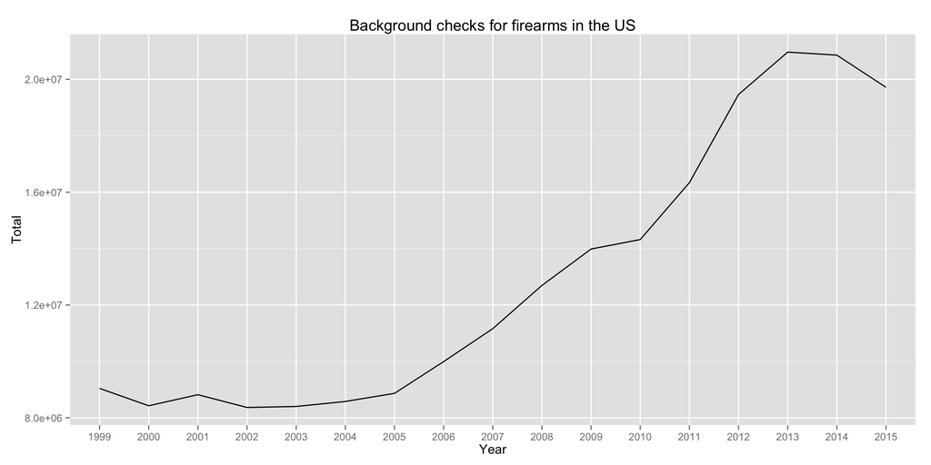

```r
ggplot(data=annual, aes(x=Year,y=Total, group=1)) +
  geom_line() +
  ggtitle("Background checks for firearms in the US") +
  labs(x="Year", y="Total")
```

### Charting the total background checks by year per capita

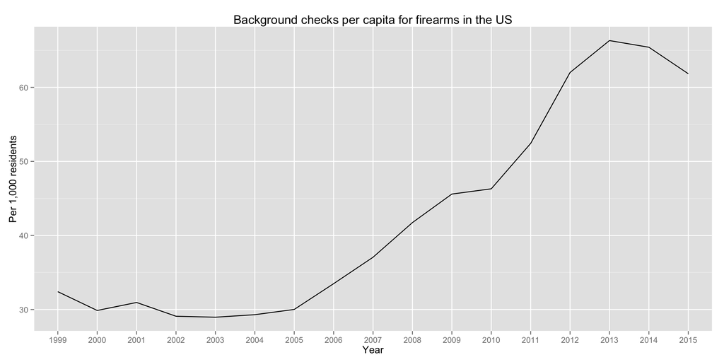

```r
ggplot(data=annual, aes(x=Year,y=percapita, group=1)) +
  geom_line() +
  ggtitle("Background checks per capita for firearms in the US") +
  labs(x="Year", y="Per 1,000 residents")
```

Not much difference, right.

### Monthly totals for the US

```r
monthly <-data.frame(tapply(nics$totals, nics$date, sum))
monthly$date <- rownames(monthly)
rownames(monthly) <- NULL
colnames(monthly) <- c("Total", "Month")
monthly<- monthly[c("Month", "Total")]
kable(head(monthly))
```

| Month | Total |
| --- | --- |
| 1998-11-01 | 21176 |
| 1998-12-01 | 870722 |
| 1999-01-01 | 585974 |
| 1999-02-01 | 690215 |
| 1999-03-01 | 741687 |
| 1999-04-01 | 638666 |

### Monthly background checks for the US per capita

```r
monthly$Month <- ymd(monthly$Month)
monthly$Year <- year(monthly$Month)

# Join by annual population from the Census
monthly <- left_join(monthly, us)
monthly$percapita <- round((monthly$Total/monthly$US)*1000,2)

us_month <- monthly[c("Month", "percapita")]
colnames(us_month) <- c("Month", "US")
kable(head(us_month))
```

| Month | US |
| --- | --- |
| 1998-11-01 | 0.08 |
| 1998-12-01 | 3.16 |
| 1999-01-01 | 2.10 |
| 1999-02-01 | 2.47 |
| 1999-03-01 | 2.66 |
| 1999-04-01 | 2.29 |

### Monthly totals for Connecticut

```r
ct <- subset(nics, state=="Connecticut")
ctpop  <- read.csv("data/historicalpop-CT.csv", stringsAsFactors=FALSE)
ct_monthly<-data.frame(tapply(ct$totals, ct$month, sum))
ct_monthly$date <- rownames(ct_monthly)
rownames(ct_monthly) <- NULL
colnames(ct_monthly) <- c("Total", "Month")
ct_monthly<- ct_monthly[c("Month", "Total")]
kable(head(ct_monthly))
```

| Month | Total |
| --- | --- |
| 1998-11 | 80 |
| 1998-12 | 6790 |
| 1999-01 | 6265 |
| 1999-02 | 8069 |
| 1999-03 | 7877 |
| 1999-04 | 9111 |

### Monthly checks per capita: US vs CT

```r
ct_monthly$Month <- as.Date(paste(ct_monthly$Month, "-01", sep=""))
ct_monthly$Month <- ymd(ct_monthly$Month)
ct_monthly$Year <- year(ct_monthly$Month)

ct_monthly <- left_join(ct_monthly, ctpop)
ct_monthly$percapita <- round((ct_monthly$Total/ct_monthly$CT)*1000,2)

ct_month <- ct_monthly[c("Month", "percapita")]
colnames(ct_month) <- c("Month", "CT")

ct_us_month <- left_join(us_month, ct_month)
```

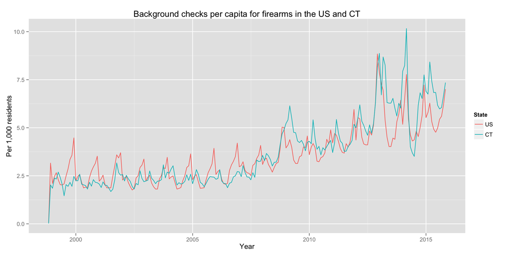

```r
# Prepping the dataframe for ggplot
ct_us_month_gg <- gather(ct_us_month, "State", "Per.Capita", 2:3)
ggplot(data=ct_us_month_gg, aes(x=Month,y=Per.Capita, group=State, colour=State)) +
  geom_line() +
  ggtitle("Background checks per capita for firearms in the US and CT") +
  labs(x="Year", y="Per 1,000 residents")
```

### Calculating the background checks per capita by state

```r
# per capita for US one more time
monthly <-data.frame(tapply(nics$totals, nics$month, sum))
monthly$date <- rownames(monthly)
rownames(monthly) <- NULL
colnames(monthly) <- c("Total", "Month")
monthly<- monthly[c("Month", "Total")]
monthly$Month <- as.Date(paste(monthly$Month, "-01", sep=""))

monthly$Month <- ymd(monthly$Month)
monthly$Year <- year(monthly$Month)

monthly <- left_join(monthly, us)
monthly$percapita <- round((monthly$Total/monthly$US)*1000,2)

by_month <- monthly[c("Month", "percapita")]
colnames(by_month) <- c("Month", "US")

by_month$Month <- substr(by_month$Month, 1, 7)

# Monthly for all states now
# Restructure data.frame

totals_only <- nics[c("month", "state", "totals")]

spreaded_totals <- spread(totals_only, state, totals)
spreaded_totals <- spreaded_totals[,colSums(is.na(spreaded_totals))<nrow(spreaded_totals)]
spreaded_totals$year <- substr(spreaded_totals$month, 1, 4)
spreaded_totals$year <- as.numeric(spreaded_totals$year)

# Setting up the loop to go through the two dataframes
# - One with annual historical state population
# - One from the NICS for total background checks

states_num <- ncol(states)
states_list <- 2:states_num

# This is the messy loop
for (i in states_list) {
  state_name <- colnames(states[i])
  temp_df <- states[c("Year", state_name)]
  colnames(temp_df) <- c("year", "Population")
  state_name <- gsub("\\.", " ", state_name)
  test_this <- grepl(state_name, colnames(spreaded_totals))
  test_sum <- sum(test_this)
  if (test_sum>0) {
    # looking just at totals
    nics_df <- spreaded_totals[c("month", "year", state_name)]
    temp_df <- left_join(temp_df, nics_df)
    temp_df$per_capita <- round((temp_df[,4]/temp_df[,2])*1000,2)
    temp_df <- temp_df[c("month", "per_capita")]
    colnames(temp_df) <- c("Month", state_name)

    by_month <- left_join(by_month, temp_df)
  }
}
```

### Charting out the state per capita results

```r
test_df <- by_month

test_df$Month <- factor(test_df$Month)

test_df <- gather(test_df, "State", "Per.Capita", 2:53)
```

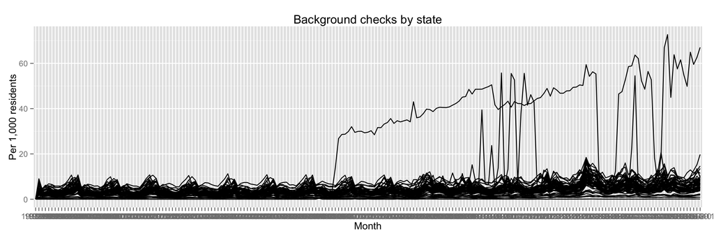

```r
ggplot(data=test_df, aes(x=test_df$Month,y=Per.Capita, group=State)) +
  geom_line() +
  ggtitle("Background checks by state") +
  labs(x="Month", y="Per 1,000 residents")
```

### Charting out the state per capita with small multiples

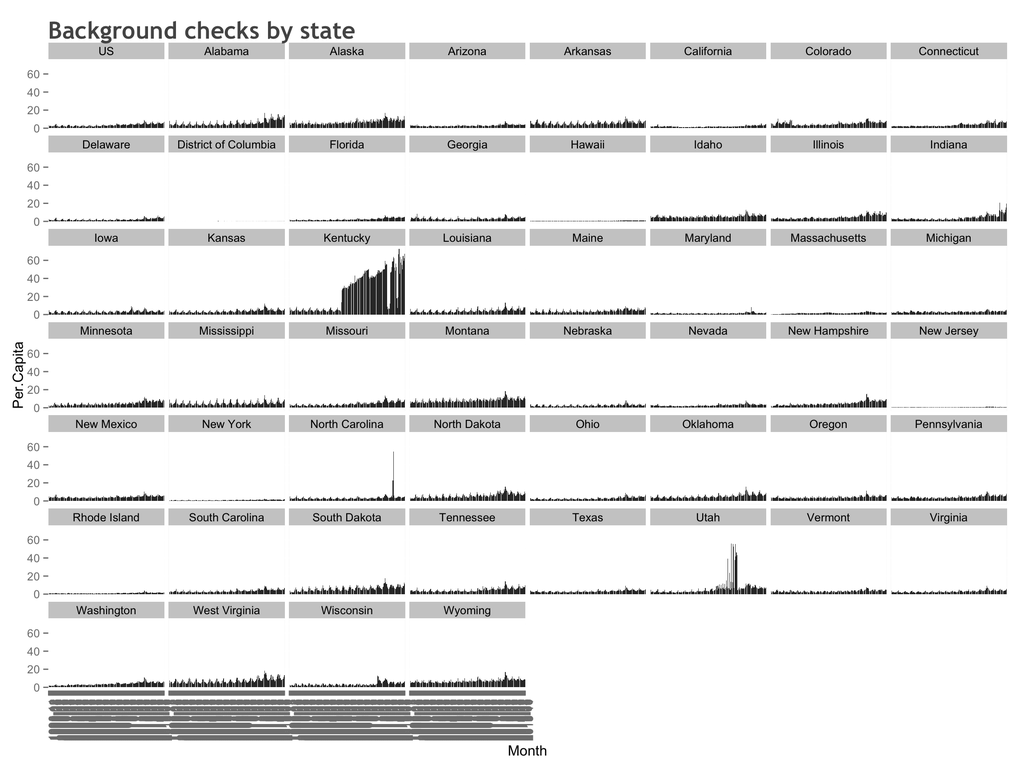

```r
ggplot(data=test_df, aes(x=Month,y=Per.Capita)) +
  geom_bar(stat="identity") +
  facet_wrap(~State) +
  ggtitle("Background checks by state") +
  theme(plot.title = element_text(family="Trebuchet MS", face="bold", size=20, hjust=0, color="#555555")) +
  theme(axis.text.x = element_text(angle=90))
```

### Adjusting CT figures for seasonality

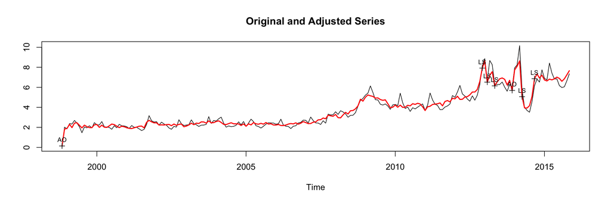

```r
# Visit [seasonal.website](http://www.seasonal.website/seasonal.html) to learn how to set up the seasonal package from the Census
Sys.setenv(X13_PATH = "/Users/andrewtran/Documents/Github/seasonal")

ct_seas <- ts(ct_month[,2],frequency=12,start=c(1998,11))
m <- seas(ct_seas)
plot(m)
```

```r
# Prepping for export as a spreadsheet
dfct <- as.data.frame(ct_seas)

ct_months_only <- ct_month$Month

dfct <- cbind(ct_months_only, dfct)
colnames(dfct) <- c("Month", "Original")
dfct2 <- data.frame(final(m))
dfct <- cbind(dfct, dfct2)

colnames(dfct) <- c("Month", "Original", "Adjusted")
dfct$Adjusted <- round(dfct$Adjusted, 2)

dfct = dfct[-1,]
kable(head(dfct))
```

|  | Month | Original | Adjusted |
| --- | --- | --- | --- |
| 1998-12 | 1998-12-01 | 2.02 | 1.83 |
| 1999-01 | 1999-01-01 | 1.85 | 1.89 |
| 1999-02 | 1999-02-01 | 2.38 | 2.30 |
| 1999-03 | 1999-03-01 | 2.33 | 1.97 |
| 1999-04 | 1999-04-01 | 2.69 | 2.43 |
| 1999-05 | 1999-05-01 | 2.42 | 2.46 |

### Adjusting US figures for seasonality

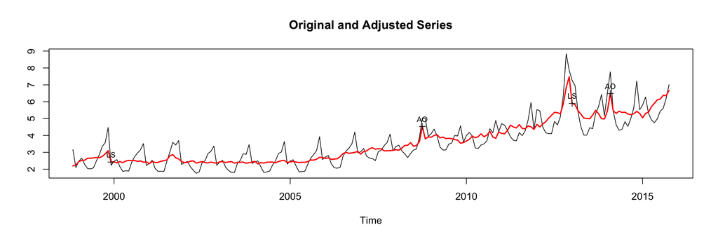

```r
## Prep dataframe
us_col <- monthly[c("Month", "percapita")]
us_col <- us_col[-1,]

## Turn it into a time series
us_tl <- ts(us_col[,2],frequency=12,start=c(1998,11))

## Adjust it for seasonality
us_m <- seas(us_tl)
plot(us_m)
```

```r
## new data.frame specifically for US
colnames(us_col) <- c("Month", "Original")
us_df <- as.data.frame(final(us_m))
us_col <- cbind(us_col, us_df)
colnames(us_col) <- c("Month", "Original", "Adjusted")
us_col$Adjusted <- round(us_col$Adjusted, 2)
kable(head(us_col))
```

|  | Month | Original | Adjusted |
| --- | --- | --- | --- |
| 2 | 1998-12-01 | 3.16 | 2.19 |
| 3 | 1999-01-01 | 2.10 | 2.25 |
| 4 | 1999-02-01 | 2.47 | 2.45 |
| 5 | 1999-03-01 | 2.66 | 2.52 |
| 6 | 1999-04-01 | 2.29 | 2.53 |
| 7 | 1999-05-01 | 2.04 | 2.65 |

### US vs. CT adjusted

```r
usct <- us_col[c("Month", "Adjusted")]
colnames(usct) <- c("Month", "US.Adjusted")
ct_adjusted <- dfct[c("Month", "Adjusted")]
colnames(ct_adjusted) <- c("Month", "CT.Adjusted")

usct <- left_join(usct, ct_adjusted)
kable(head(usct))
```

| Month | US.Adjusted | CT.Adjusted |
| --- | --- | --- |
| 1998-12-01 | 2.19 | 1.83 |
| 1999-01-01 | 2.25 | 1.89 |
| 1999-02-01 | 2.45 | 2.30 |
| 1999-03-01 | 2.52 | 1.97 |
| 1999-04-01 | 2.53 | 2.43 |
| 1999-05-01 | 2.65 | 2.46 |

### Charting out the seasonally adjusted per capita data

```r
us_seas_only <- us_col[c("Month", "Adjusted")]
us_seas_only$Month <- as.character(us_seas_only$Month)
colnames(us_seas_only) <- c("Month", "US")
us_seas_only$US <- as.numeric(as.character(us_seas_only$US))
months_only <- as.character(us_seas_only$Month)

adj_seas <- by_month
adj_seas_num <- 2:ncol(adj_seas)
adj_seas_list <- colnames(adj_seas)

adj_seas$Month <- as.Date(adj_seas$Month, format="%Y-%m")

for (i in adj_seas_num) {
  adj_seas_col <- colnames(adj_seas[i])
  seas_df_subset <- adj_seas[c("Month", adj_seas_col)]
  subset_series <- ts(seas_df_subset[,2],frequency=12,start=c(1998,11))
  subset_seas <- seas(subset_series)
  subset_seas_df <- as.data.frame(final(subset_seas))

  subset_seas_df <- subset_seas_df[-1,]
  months_only_df <- months_only
  months_only_df <- as.data.frame(cbind(months_only_df, subset_seas_df))
  colnames(months_only_df) <- c("Month", adj_seas_col)
  months_only_df$Month <- as.character(months_only_df$Month)
  months_only_df[,2] <- as.numeric(as.character(months_only_df[,2]))
  months_only_df[,2] <- round(months_only_df[,2], 2)

  if (!exists("months_only_all")) {
    months_only_all <- left_join(us_seas_only, months_only_df)
  } else {
    months_only_all <- left_join(months_only_all, months_only_df)
  }

}
kable(head(months_only_all[,1:5]))
```

| Month | US | Alabama | Alaska | Arizona |
| --- | --- | --- | --- | --- |
| 1998-12-01 | 2.19 | 4.59 | 5.38 | 2.75 |
| 1999-01-01 | 2.25 | 4.54 | 5.61 | 2.73 |
| 1999-02-01 | 2.45 | 4.63 | 5.47 | 2.81 |
| 1999-03-01 | 2.52 | 4.65 | 5.65 | 2.89 |
| 1999-04-01 | 2.53 | 4.53 | 5.83 | 2.96 |
| 1999-05-01 | 2.65 | 4.59 | 5.67 | 2.91 |

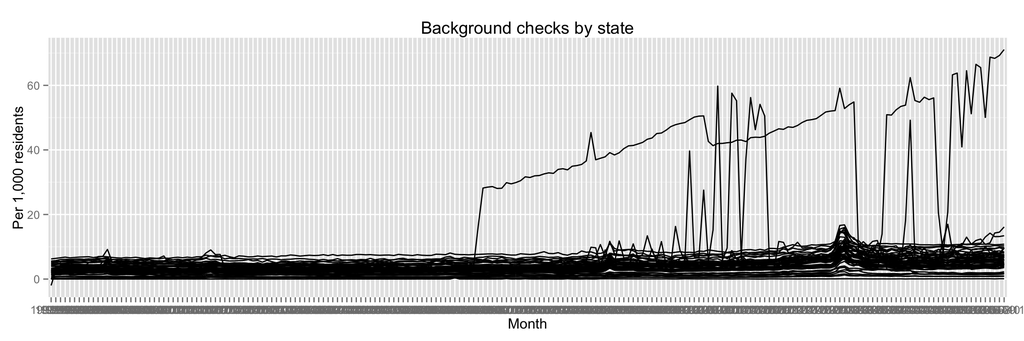

```r
# Exporting seasonally-adjusted figures to csv
write.csv(months_only_all, "data/states_monthly_adjusted.csv")

# Charting out with ggplot
for_gg <- months_only_all

# Adjusting timestamp just for cosmetic reasons
for_gg$Month <- substring(for_gg$Month, 1,7)

# Prepping the time stamps for ggplot
for_gg$Month <- factor(for_gg$Month)

# Reshaping the dataframe for ggplot and also D3
for_gg <- gather(for_gg, "State", "Per.Capita", 2:53)

## Charting it in one line graph
ggplot(data=for_gg, aes(x=for_gg$Month,y=Per.Capita, group=State)) +
  geom_line() +
  ggtitle("Background checks by state") +
  labs(x="Month", y="Per 1,000 residents")
```

### Charting it using small multiples

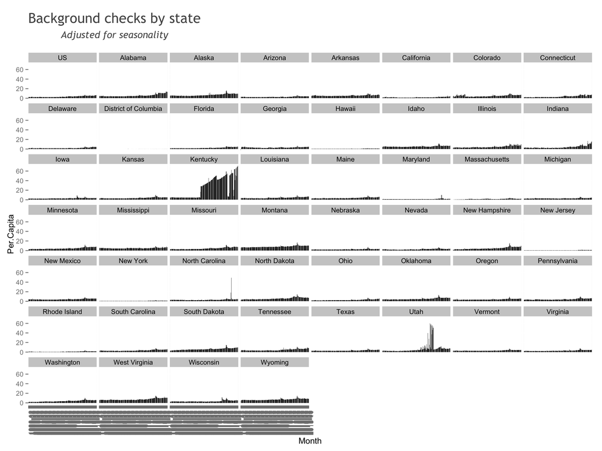

```r
ggplot(data=for_gg, aes(x=Month,y=Per.Capita)) +
  geom_bar(stat="identity") +
  facet_wrap(~State) +
  ggtitle(expression(atop("Background checks by state", atop(italic("Adjusted for seasonality"), "")))) +
  theme(plot.title = element_text(family="Trebuchet MS", face="bold", size=20, hjust=0, color="#555555")) +
  theme(axis.text.x = element_text(angle=90))
```

```r
# Exporting for D3
write.table(for_gg, file="seasonally_adjusted.tsv", quote=FALSE, sep='\t', col.names=NA)
```